# anchoredDistr: a Package for the Bayesian Inversion of Geostatistical Parameters with Multi-type and Multi-scale Data

### 5.2 Applying dimension reduction to time series

Even though we have the time series of drawdown, we cannot use these 100 individual values to calculate the likelihood because they are correlated and the multivariate likelihood distribution would be 100-dimensional. Such dimensionality would require an unrealistic number of realizations to resolve, known as "the curse of dimensionality." To overcome this obstacle, dimension reduction is needed and the method to use depends on the type of non-local data $z_b$. For this example, we will simply use the `min()` function to collect the minimum head value in the time series since the observed head reduces and converges to a stable head value with time (Figure 7). The *anchoredDistr* package can handle any non-parameterized function, such as `min()`, or a parameterized function if initial values for each parameter are given and the `nls()` function (R Core Team 2016) can perform the fitting (see the package vignette for an example). The `reduceData()` function is used to perform the dimension reduction on the time series:

```r
  pumping.min <- reduceData(pumping, min)
  plotMAD(pumping.min, "realizations")
```

The `reduceData()` function returns a `"MADproject"` object with a `realizations` slot with reduced dimensions. The reduced data can be viewed by calling `plotMAD()` with the string "realizations". The plot shows the distributions of each parameter for each sample. In this case, Figure 10 shows the minimum head value distribution for the three samples, which will be used to calculate the three likelihood samples.

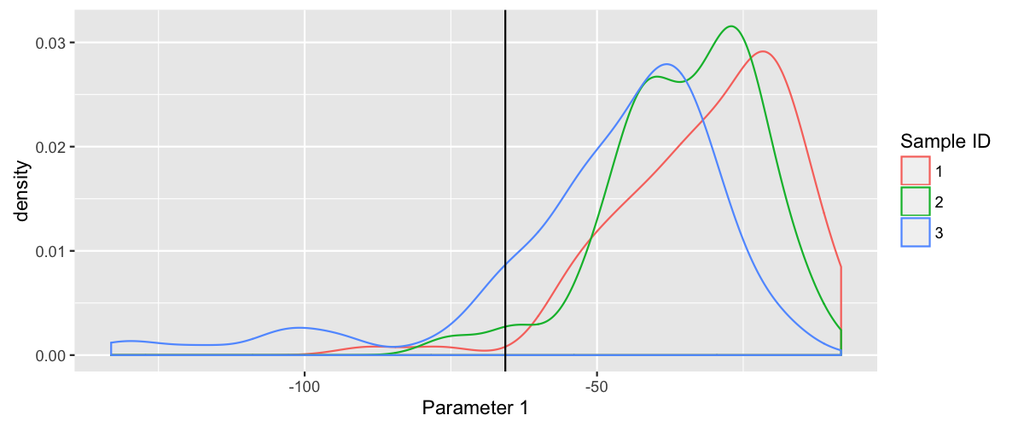

Figure 10: The reduced $z_b$ data (minimum of drawdown curve) for Example 2. Distributions are estimated from the realizations’ reduced data per sample.

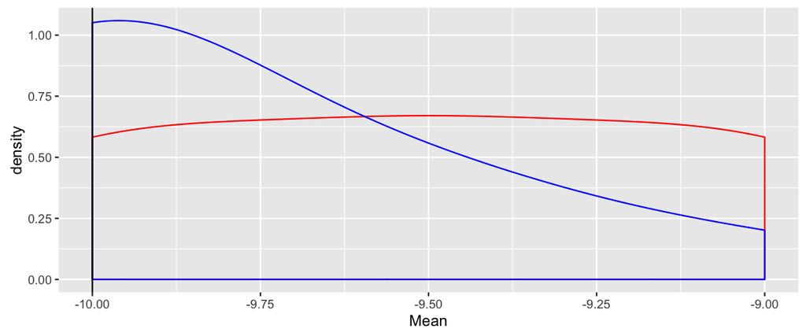

Figure 11: The prior (red) and posterior (blue) distributions with the true value (black) for the mean $\ln K$ locations in Example 2.

```r
  pumping.min <- calcLikelihood(pumping.min)
  pumping.min <- calcPosterior(pumping.min)
  plotMAD(pumping.min, "posteriors")
```

## 6 Summary

The examples given above show how the *anchoredDistr* package allows flexible post-processing of results by virtue of the MAD software such that users can apply their own post-processing analyses, such as dimension-reduction techniques. The first example shown here is available as external and internal datasets in the *anchoredDistr* package. The second example is also included in *anchoredDistr* and is further detailed in the package vignette. The release version of the *anchoredDistr* package is hosted on CRAN and the development version is hosted on GitHub, which can be accessed by calling `devtools::install_github("hsavoy/anchoredDistr")` or by downloading from http://hsavoy.github.io/anchoredDistr.

## 7 Acknowledgements

This work was supported by the National Science Foundation under grant EAR-1011336, "The Method of Anchored Distributions (MAD): Principles and Implementation as a Community Resource." Any opinions, findings and conclusions or recommendations expressed in this material are those of the authors and do not necessarily reflect the views of the National Science Foundation.

### 7.1 Supplementary materials

Supplementary materials are available in addition to this article. It can be downloaded at RJ-2017-034.zip

### 7.2 CRAN packages used

gstat, spBayes, spTimer, anchoredDistr, devtools, RSQLite, np, plyr, dplyr, ggplot2

### 7.3 CRAN Task Views implied by cited packages

Bayesian, ChemPhys, Databases, Econometrics, ModelDeployment, NetworkAnalysis, Phylogenetics, Spatial, SpatioTemporal, TeachingStatistics, TimeSeries

K. S. Bakar and S. K. Sahu. spTimer: Spatio-temporal Bayesian modeling using R. *Journal of Statistical Software*, 63(15): 32, 2015.

J. Carrera, A. Alcolea, A. Medina, J. Hidalgo and L. J. Slooten. Inverse problem in hydrogeology. *Hydrogeology Journal*, 13(1): 206–222, 2005. URL https://doi.org/10.1007/s10040-004-0404-7.

X. Chen, H. Murakami, M. S. Hahn, G. E. Hammond, M. L. Rockhold, J. M. Zachara and Y. Rubin. Three-dimensional Bayesian geostatistical aquifer characterization at the Hanford 300 Area using tracer test data. *Water Resources Research*, 48(6): W06501, 2012. URL https://doi.org/10.1029/2011wr010675.

A. O. Finley, S. Banerjee and A. E. Gelfand. spBayes for large univariate and multivariate point-referenced spatio-temporal data models. *Journal of Statistical Software*, 63(13): 1–28, 2015. URL http://www.jstatsoft.org/v63/i13.

P. Goovaerts. Geostatistics in soil science: State-of-the-art and perspectives. *Geoderma*, 89(1–2): 1–45, 1999. URL https://doi.org/10.1016/s0016-7061(98)00078-0.

W. Harbaugh and M. G. Mcdonald. User’s documentation for MODFLOW-96 , an update to the U.S. Geological Survey modular finite-difference ground-water flow model, Open File Report 96-485. U.S. Geological Survey. 1996.

T. Hayfield and J. S. Racine. Nonparametric econometrics: The np package. *Journal of Statistical Software*, 27(5): 2008. URL http://www.jstatsoft.org/v27/i05/.

F. Heße, H. Savoy, C. A. Osorio-Murillo, J. Sege, S. Attinger and Y. Rubin. Characterizing the impact of roughness and connectivity features of aquifer conductivity using Bayesian inversion. *Journal of Hydrology*, 531: 73–87, 2015. URL https://doi.org/10.1016/j.jhydrol.2015.09.067.

M. Hohn. *Geostatistics and petroleum geology (2nd ed.).* Kluwer, 1962.

P. Kitanidis. *Introduction to geostatistics: Applications in hydrogeology.* Cambridge University Press, 2008.

O. Kolditz, S. Bauer, L. Bilke, N. Böttcher, J. O. Delfs, T. Fischer, U. J. Görke, T. Kalbacher, G. Kosakowski, C. I. McDermott, et al. OpenGeoSys: An open-source initiative for numerical simulation of Thermo-Hydro-Mechanical/chemical (THM/C) processes in porous media. *Environmental Earth Sciences*, 67(2): 589–599, 2012. URL https://doi.org/10.1007/s12665-012-1546-x.

D. G. Krige. A statistical approach to some basic mine valuation problems on the Witwatersrand. *Journal of the Chemical, Metallurgical and Mining Society of South Africa*, 52(6): 119–139, 1951. URL https://doi.org/10.2307/3006914.

F. Lindgren and HåRue. Bayesian spatial modelling with R-INLA. *Journal of Statistical Software*, 63(19): 1–25, 2015. URL https://doi.org/10.18637/jss.v063.i19.

G. Matheron. *Traité De Géostatistique Appliquée.* Paris: Editions Technip; Editions Technip, 1962.

H. Murakami, X. Chen, M. S. Hahn, Y. Liu, M. L. Rockhold, V. R. Vermeul, J. M. Zachara and Y. Rubin. Bayesian approach for three-dimensional aquifer characterization at the Hanford 300 Area. *Hydrology and Earth System Sciences*, 14(10): 1989–2001, 2010. URL https://doi.org/10.5194/hess-14-1989-2010.

C. a. Osorio-Murillo, M. W. Over, H. Savoy, D. P. Ames and Y. Rubin. Software framework for inverse modeling and uncertainty characterization. *Environmental Modelling & Software*, 66: 98–109, 2015. URL https://doi.org/10.1016/j.envsoft.2015.01.002.

M. W. Over, U. Wollschlaeger, C. a. Osorio-Murillo and Rubin. Bayesian inversion of Mualem-Van Genuchten parameters in a multilayer soil profile: A data-driven assumption-free likelihood function. *Water Resources Research*, 51(2): 861–884, 2015. URL https://doi.org/10.1002/2013wr014956.received.

E. J. Pebesma. Multivariable geostatistics in S: The gstat package. *Computers & Geosciences*, 30: 683–691, 2004.

R Core Team. *R: A language and environment for statistical computing.* Vienna, Austria: R Foundation for Statistical Computing, 2016. URL https://www.R-project.org/.

Y. Rubin, X. Chen, H. Murakami and M. Hahn. A Bayesian approach for inverse modeling, data assimilation, and conditional simulation of spatial random fields. *Water Resources Research*, 46(October 2009): 1–23, 2010. URL https://doi.org/10.1029/2009wr008799.

H. Wickham. *ggplot2: Elegant graphics for data analysis.* Springer-Verlag, 2009. URL http://ggplot2.org.

H. Wickham. The split-apply-combine strategy for data analysis. *Journal of Statistical Software*, 40(1): 1–29, 2011. URL http://www.jstatsoft.org/v40/i01/.

H. Wickham and W. Chang. *devtools: Tools to make developing r packages easier.* 2016. URL https://CRAN.R-project.org/package=devtools. R package version 1.11.1.

H. Wickham and R. Francois. *dplyr: A grammar of data manipulation.* 2016. URL https://CRAN.R-project.org/package=dplyr. R package version 0.5.0.

H. Wickham, D. A. James and S. Falcon. *RSQLite: SQLite interface for R.* 2014. URL https://CRAN.R-project.org/package=RSQLite. R package version 1.0.0.

Y. Yang, M. Over and Y. Rubin. Strategic placement of localization devices (such as pilot points and anchors) in inverse modeling schemes. *Water Resources Research*, 48(8): W08519, 2012. URL https://doi.org/10.1029/2012wr011864.